# Vehicle Detection and Tracking

In this project, we will use Histogram of Oriented Gradients (HOG) features to detect vehicles in images.

## The Dataset

As part of this project, we were given approximately 9000 car images and 9000 non-car images, all of which were 64x64 pixels. We used 80% of the data for training, and 20% for validation. To ensure that the training/validation split was repeatable in our experiments, we spun off a separate file `data.py` which has the single method `get()` for returning the training and validation images.

> Internally, `data.get()` seeds a random number generator with a repeatable seed, and then shuffles the data.

```python
import warnings; warnings.simplefilter('ignore')
import data

carTrain, carValid, notCarTrain, notCarValid = data.get()

print(len(carTrain) +  len(carValid), "car images: ")
print(len(carTrain), "training images")
print(len(carValid), "validation images")
print('--------------')
print(len(notCarTrain) + len(notCarValid), "non-car images:")
print(len(notCarTrain), "non-car training images")
print(len(notCarValid), "non-car validation images")
```

```
8792 car images:
7033 training images
1759 validation images
--------------
8968 non-car images:
7174 non-car training images
1794 non-car validation images
```

Furthermore, due to discrepancies in how `.jpg's` and `.png's` are loaded in python, we created the utility function `utils.load(imgPath)`, which will always load an image in RGB format, where the values are represented in the range `[0,255]`. Using this code throughout the project ensures that data formatting bugs do not creep in throughout the code. The following snippet shows how to load an image with this utility function, as well as some examples of car and non-car images in the dataset:

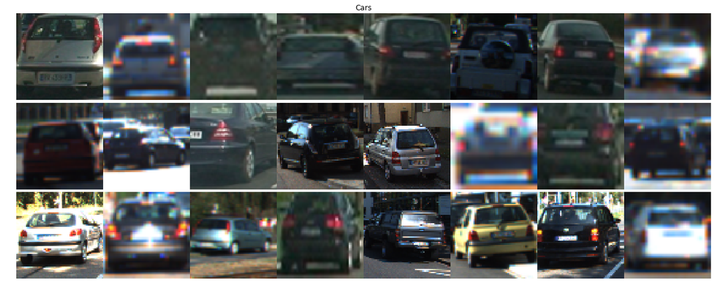

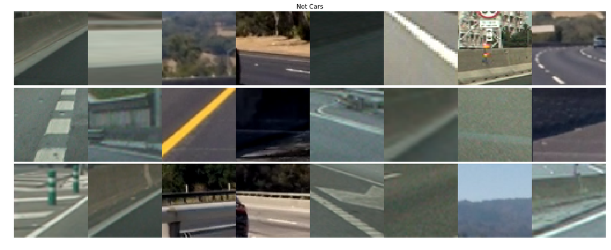

```python
import matplotlib.pyplot as plt
import numpy as np
import utils
%matplotlib inline

def show_examples( dataset, title ):
    fig,axes = plt.subplots(3,8, figsize=(16,6.5))
    axes = np.array(axes).ravel()
    fig.subplots_adjust(hspace=0, wspace=0, bottom=0, left=0, top=.95, right=1)

    for i,ax in enumerate(axes):
        ax.imshow( utils.load( dataset[i] ) )
        ax.axis('off')
    plt.suptitle(title)
    plt.show()

show_examples( carTrain, "Cars" )
show_examples( notCarTrain, "Not Cars" )
```

## Histogram of Oriented Gradients (HOG)

In this project, we explore how well we can detect cars with HOG features. Hence the workhorse of this project is the `skimage.feature.hog` method. We will always be examining square images and subimages, so our `utils.get_hog_features` method simply wraps the `hog` function to ensure that the selection is always square. Among the choices for our hog features, we have to choose:

1. how many pixels to include in each cell
2. how many cells per block (blocks are used to normalize the gradients across all of the cells in a block)
3. how many orientation bins to use for each cell

Let's look at how those features look for several choices:

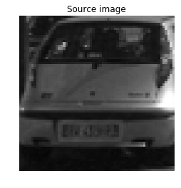

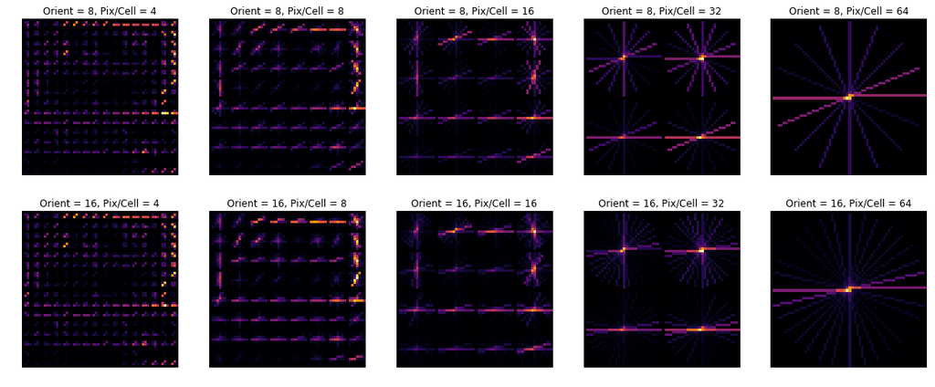

```python
import cv2

img = utils.load(carTrain[0])
gray = cv2.cvtColor( img, cv2.COLOR_RGB2GRAY )

# Show the source image
fig, ax = plt.subplots(1,1, figsize=(4,4))
ax.imshow( gray, cmap = 'gray' )
ax.axis('off')
ax.set_title("Source image")

orients = [8,16]
pixs_per_cell = [4,8,16,32,64]
fig, axes = plt.subplots(len(orients), len(pixs_per_cell), figsize=(20,8))
for row, orient in enumerate(orients):
    for col, pix_per_cell in enumerate(pixs_per_cell):
        features, hog_image = utils.get_hog_features( gray, orient, pix_per_cell, 2, 'L1', True, True )
        ax = axes[row][col]
        ax.imshow(hog_image,cmap='inferno')
        ax.axis('off')
        ax.set_title("Orient = " + str(orient) + ", Pix/Cell = " + str(pix_per_cell))
```

What we see is that choosing a low number of pixels per cell gives us more features. However, since the orientation bins are aggregated over fewer pixels, this may lead to noise dominating our features. Conversely, if we choose a large number of pixels per cell, then we get fewer features, although those features will essentially be averaged over more cells, so they should be more robust. Therefore, we will probably want something right in the middle of the above plot. However, we will defer making an exact choice until we discuss another important consideration when extracting HOG features:

*which colorspace to use...*

One extremely import thing to notice about HOG features is that they are computed on a per-channel basis. In the above example, we converted to grayscale, then looked at the HOG features of that single-channel image. If, however, we had something like an RGB image, then we would have HOG features for the R,G, and B channels individually:

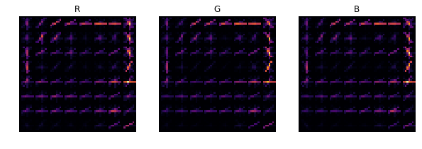

```python
def showHogFeatures(img, channelNames):
    channels = img.shape[-1]
    fig, axes = plt.subplots(1, channels, figsize=(10,10))
    for channel in range(channels):
            features, hog_image = utils.get_hog_features(img[:,:,channel], 8, 8, 2, 'L1', True, True )
            ax = axes[channel]
            ax.imshow(hog_image, cmap = 'inferno')
            ax.axis('off')
            ax.set_title(channelNames[channel])

showHogFeatures( img, ['R','G','B'] )
```

Hence the features we get will be extremely dependent on the colorspace we use, since we have to compute them on a channel-by-channel basis.

Therefore, since all of the input data (returned by `utils.load()`) are RGB images, we created another simple utility function `utils.rgbTo` to convert an RGB image to the `hsv`, `hls`, `gray`, `ycrcb`, and `luv` colorspaces, which will enable us to easily test different colorspaces. For example, to convert to the `luv` colorspace and extract the features for the L, U, and V channels, we could use the folowing code snippet:

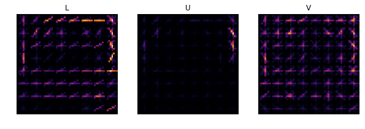

```python
luv = utils.rgbTo(img, 'luv')
showHogFeatures( luv, ['L','U','V'] )
```

Just by visually comparing the RGB and LUV HOG features, we can see how different they are. But instead of choosing all of the feature parameters (colorspace, pixels per cell, cells per block, and orientations) arbitrarily, we wil choose those parameters based on what performs best across the validation data.

So just to recap, our features are going to be dependent on the following choices:

1. Colorspace: RGB, LUV, ...
2. Channel: Which channel from colorspace to compute HOG features for. For example, if you just want the features for the R-channel in an RGB image, then you want channel 0. Alternatively, we also allow the feature vector to be a concatenation of `all` channels.
3. Orientation bins
4. Pixels per cell
5. Cells per block
6. Which norm to use when normalizing the features across blocks

These are the only features we consider when computing the feature vector, so naturally, we will define a single utility function that we will use to always compute our features, namely, `utils.features(...)`. If you don't specify one of these parameters, then its value will be taken from `defaults.py`. Configuring our code in this way allows us to change defaults globally across our project after we have settled on choices for these parameters. But for now, we still need to choose these parameters!

To train our code, we will use a support vector machine. However, since we may want to experiment with several SVM parameters, we will pickle the features for each set of chosen parameters. We want to do this because computing the features for a dataset of our size can take a very long time, and it doesn't make sense to compute these features multiple times. So without further ado, let's compute and pickle those features if they don't already exist.

> If you really do run all of these criterion, you should spin up several threads to do the computation on a server. The code does not natively multi-thread. Furthermore, this will take hours to run and require in excess of 50GB of disk space. So I do not recommend running the full routine on your own unless you have time.

```python
import os, pickle

def picklename(colorspace, channel, orient, pix_per_cell, cell_per_block, block_norm ):
    return colorspace + "_" + str(channel) + "_" + str(orient) + "_" + str(pix_per_cell) + "_" + str(cell_per_block) + "_" + block_norm + ".p"

def saveFeatures(filename, colorspace, channel, orient, pix_per_cell, cell_per_block, block_norm ):

    # Define the feature_extractor
    feature_extractor = lambda img : utils.features( img, colorspace, channel, orient, pix_per_cell, cell_per_block, block_norm )
    allFeatures = lambda dataset : [ feature_extractor(utils.load(file)) for file in dataset ]

    # Load the data
    labels = ['carTrain', 'carValid', 'notCarTrain', 'notCarValid']

    # Now for each dataset, compute the features
    features = {}
    for dataset, label in zip( data.get(), labels ):
        features[label] = allFeatures(dataset)

    # Now pickle the features
    pickle.dump(features, open(filename, "wb"))
    return features

def loadFeatures(colorspace, channel, orient, pix_per_cell, cell_per_block, block_norm, reload = True ):

    dir = 'C:/Users/matth/Desktop/pickled_features'
    filename = picklename(colorspace, channel, orient, pix_per_cell, cell_per_block, block_norm )
    path = os.path.join(dir,filename)
    if not os.path.isfile(path):
        # We still need to compute the features
        # Put a placeholder file so that other threads don't start this
        open(path,'a').close()
        return saveFeatures(path, colorspace, channel, orient, pix_per_cell, cell_per_block, block_norm )
    else:
        if reload:
            return pickle.load(open(path, "rb"))
        else:
            return None

def pickleFeatures():
    for colorspace in ['rgb', 'hsv', 'luv', 'ycrcb', 'hls']:
        for channel in [0,'all']:
            for orient in [4, 8, 16]:
                for pix_per_cell in [8, 16]:
                    for cell_per_block in [1, 2, 3]:
                        for block_norm in ['L1' ]:
                            loadFeatures(colorspace, channel, orient, pix_per_cell, cell_per_block, block_norm, False )
pickleFeatures()
```

Now, with our features pickled, we can try to train and validate a support vector machine. To accomplish this, we

1. Choose an SVM type (for the purpose of this project, this will always be a `LinearSVM`)
2. Choose the feature parameters
3. Load the training and validation features for the chosen parameter set
4. Scale (normalize) the training features using a `StandardScaler`
5. Fit the provided SVM to the training data
6. Compute the SVM score on the validation data

Since we have pickled all of the parameters, we can quickly generate the scores for each of the parameter types, and COULD (if desired) try to optimize the SVM type or parameters.

```python
def formatFeatures( features ):
    features = np.array(features)
    return features.reshape(features.shape[0], -1)

def train(clf, colorspace, channel, orient, pix_per_cell, cell_per_block, block_norm ):

    # First, load the features
    features = loadFeatures( colorspace, channel, orient, pix_per_cell, cell_per_block, block_norm )
    carTrainFeatures = formatFeatures( features['carTrain'] )
    carValidFeatures = formatFeatures( features['carValid'] )
    notCarTrainFeatures = formatFeatures( features['notCarTrain'] )
    notCarValidFeatures = formatFeatures( features['notCarValid'] )

    # Next, scale the training features
    X = np.vstack((carTrainFeatures, notCarTrainFeatures)).astype(np.float64)
    scaler = StandardScaler().fit(X)
    scaled_X = scaler.transform(X)

    # Define the training labels
    y = np.hstack((np.ones(len(carTrainFeatures)), np.zeros(len(notCarTrainFeatures))))

    # and fit the classifier to the data
    clf.fit(scaled_X, y)

def validate(clf, colorspace, channel, orient, pix_per_cell, cell_per_block, block_norm):

    # First, load the features
    features = loadFeatures( colorspace, channel, orient, pix_per_cell, cell_per_block, block_norm )
    carTrainFeatures = formatFeatures( features['carTrain'] )
    carValidFeatures = formatFeatures( features['carValid'] )
    notCarTrainFeatures = formatFeatures( features['notCarTrain'] )
    notCarValidFeatures = formatFeatures( features['notCarValid'] )

    # Next, generate a scaler based on the training features
    X = np.vstack((carTrainFeatures, notCarTrainFeatures)).astype(np.float64)
    scaler = StandardScaler().fit(X)

    # Finally, compute the score
    X = np.vstack((carValidFeatures, notCarValidFeatures)).astype(np.float64)
    scaled_X = scaler.transform(X)
    y = np.hstack((np.ones(len(carValidFeatures)), np.zeros(len(notCarValidFeatures))))
    return clf.score(scaled_X, y)
```

Like before, once we are done, it makes sense to pickle the SVMs:

```python
from sklearn.svm import LinearSVC
from sklearn.preprocessing import StandardScaler

def saveSVM(filename, colorspace, channel, orient, pix_per_cell, cell_per_block, block_norm ):

    # Train and validate the SVM
    clf = LinearSVC()
    train(clf, colorspace, channel, orient, pix_per_cell, cell_per_block, block_norm )

    # Then pickle it and return it
    pickle.dump(clf, open(filename, "wb"))
    return clf

def loadSVM(colorspace, channel, orient, pix_per_cell, cell_per_block, block_norm, reload = True ):

    dir = 'pickled_svms'
    filename = picklename(colorspace, channel, orient, pix_per_cell, cell_per_block, block_norm )
    path = os.path.join(dir,filename)
    if not os.path.isfile(path):
        # We still need to train the svm
        # Put a placeholder file so that other threads don't start this
        open(path,'a').close()
        return saveSVM(path, colorspace, channel, orient, pix_per_cell, cell_per_block, block_norm )
    else:
        if reload:
            return pickle.load(open(path, "rb"))
        else:
            return None

def pickleSVMs():
    for colorspace in ['rgb', 'hsv', 'luv', 'ycrcb', 'hls']:
        for channel in [0,'all']:
            for orient in [4, 8, 16]:
                for pix_per_cell in [8, 16]:
                    for cell_per_block in [1, 2, 3]:
                        for block_norm in ['L1']:
                            loadSVM(colorspace, channel, orient, pix_per_cell, cell_per_block, block_norm, False )

pickleSVMs()
```

And finally, we can compute the scores for all of these trained svms. Once again, we will pickle the scores so that we can quickly access them later:

```python
import os, pickle

class Params():
    def __init__(self, colorspace, channel, orient, pix_per_cell, cell_per_block, block_norm):
        self.colorspace = colorspace
        self.channel = channel
        self.orient = orient
        self.pix_per_cell = pix_per_cell
        self.cell_per_block = cell_per_block
        self.block_norm = block_norm

    def fields(self):
        return (self.colorspace,self.channel,self.orient,self.pix_per_cell,self.cell_per_block,self.block_norm)

    def __eq__(self, rhs):
        return self.fields() == rhs.fields()

    def __hash__(self):
        return hash(self.fields())

    def __str__(self):
        s = ''
        s += 'colorspace: ' + self.colorspace + ', '
        s += 'channel: ' + str(self.channel) + ', '
        s += 'orient: ' + str(self.orient) + ', '
        s += 'pix_per_cell: ' + str(self.pix_per_cell) + ', '
        s += 'cell_per_block: ' + str(self.cell_per_block) + ', '
        s += 'block_norm: ' + self.block_norm
        return s

def loadSVMScores():

    # First, load our scores from file
    filename = 'pickled_svms/scores.p'
    if os.path.isfile(filename):
        scores = pickle.load(open(filename, "rb"))
    else:
        scores = {}

    # Now compute all of the scores that aren't already in the dictionary
    for colorspace in ['rgb', 'hsv', 'luv', 'ycrcb', 'hls']:
        for channel in [0,'all']:
            for orient in [4, 8, 16]:
                for pix_per_cell in [8, 16]:
                    for cell_per_block in [1, 2, 3]:
                        for block_norm in ['L1']:
                            params = Params(colorspace, channel, orient, pix_per_cell, cell_per_block, block_norm)
                            if params not in scores:
                                timer = utils.Timer()
                                svm = loadSVM(colorspace, channel, orient, pix_per_cell, cell_per_block, block_norm )
                                scores[params] = validate(svm, colorspace, channel, orient, pix_per_cell, cell_per_block, block_norm)
                                timer.print("seconds to validate")
                                pickle.dump(scores, open(filename, "wb"))
    return scores

# Get the scores
scores = loadSVMScores()

# Now, let's look at the top 5 options
scoreList = [ [key,scores[key]] for key in scores ]
sortedScores = sorted( scoreList, key = lambda x : x[1], reverse = True )

print("Top scores:")
for i in range(10):
    print( "Score:", sortedScores[i][1], ",", sortedScores[i][0] )
```

```
Top scores:
Score: 0.991274978891 , colorspace: ycrcb, channel: all, orient: 16, pix_per_cell: 16, cell_per_block: 2, block_norm: L1
Score: 0.990149169716 , colorspace: ycrcb, channel: all, orient: 16, pix_per_cell: 16, cell_per_block: 3, block_norm: L1
Score: 0.989867717422 , colorspace: ycrcb, channel: all, orient: 16, pix_per_cell: 8, cell_per_block: 3, block_norm: L1
Score: 0.989586265128 , colorspace: hsv, channel: all, orient: 16, pix_per_cell: 8, cell_per_block: 2, block_norm: L1
Score: 0.989304812834 , colorspace: luv, channel: all, orient: 16, pix_per_cell: 8, cell_per_block: 2, block_norm: L1
Score: 0.988460455953 , colorspace: hsv, channel: all, orient: 16, pix_per_cell: 8, cell_per_block: 3, block_norm: L1
Score: 0.988460455953 , colorspace: luv, channel: all, orient: 16, pix_per_cell: 8, cell_per_block: 3, block_norm: L1
Score: 0.988179003659 , colorspace: ycrcb, channel: all, orient: 8, pix_per_cell: 8, cell_per_block: 2, block_norm: L1
Score: 0.987897551365 , colorspace: luv, channel: all, orient: 16, pix_per_cell: 16, cell_per_block: 2, block_norm: L1
Score: 0.987616099071 , colorspace: ycrcb, channel: all, orient: 16, pix_per_cell: 8, cell_per_block: 2, block_norm: L1
```

We have entered these defaults into `defaults.py`, and will henceforth use the best result.

## Sliding Window Search

Great. So we have trained an SVM to fit our data fairly accurately. Now we need to use it. The issue is that the SVM expects 64 x 64 pixel images, while the camera images where we want to search for cars are 1280 x 720 pixels (width x height). So what we are going to do is to slide a 64 x 64 pixels window over the image, and search for cars in each window. However, as the following figure shows, the problem is that 64 x 64 pixels is simply too small of a window when the vehicles are close to the camera. This actually introduces two problems:

1. It increases the runtime.
2. It means that any detections must be false positives.

> `search_regions.generate_rectangles` is actually a cool interactive generator (when not run in IPython) that let's you create very intricate search patterns. I encourage you to play around with the GUI, although we won't be using it to generate the main results of this project.

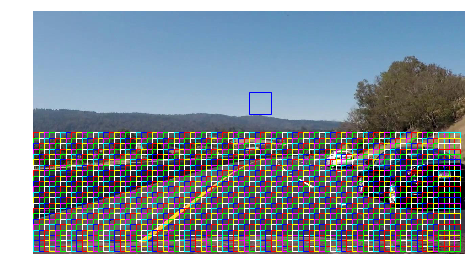

```python
import defaults, search_regions, utils
%matplotlib inline

img = utils.load( 'project_video/frame741.jpg' )
pix_per_cell = defaults.pix_per_cell()
cell_per_block = defaults.cell_per_block()

search_regions.generate_rectangles(img, [1], pix_per_cell, cell_per_block, ystop = img.shape[0], save = False)
```

Therefore, we are going limit the search the 2/3 of the image height:

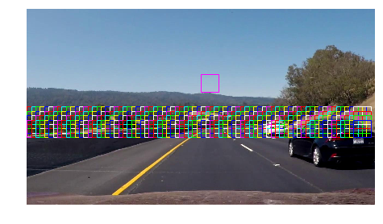

```python
import math
search_regions.generate_rectangles(img, [1], pix_per_cell, cell_per_block, ystop = math.floor(img.shape[0] * .66), save = False)
```

The next problem we need to solve is that our small search rectangles won't be able to capture the larger vehicles close to the camera. For that purpose, we will downsample the image (so that a 64 x 64 window appears larger). Furthermore, for each scale, we define a different stopping point. In fact, we came up with a rule for choosing the stopping point:

1. If `scale <= 1`, then `ystop = .66 * height`
2. If `scale >= 4`, then `ystop = height`
3. Otherwise, linearly interpolate between these values

The following figures show what the search windows would look like for several scales.

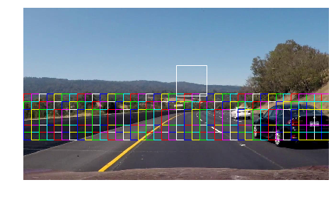

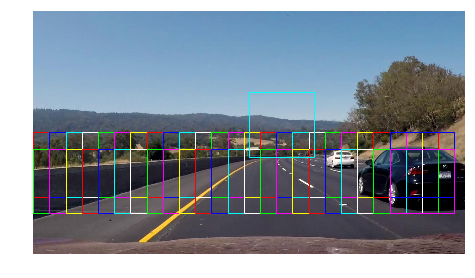

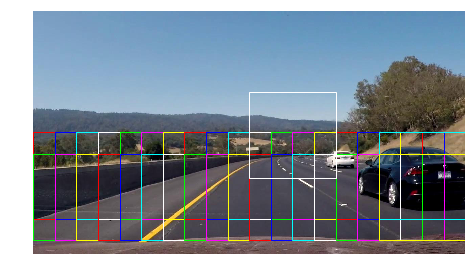

```python
scales = [2,3,4]
height = img.shape[0]
for scale in scales:
    search_regions.generate_rectangles(img, [scale], pix_per_cell, cell_per_block, ystop = utils.ystop(height, scale), save = False)
```

## Heatmapping

The next problem we need to tackle is how we are going to handle multiple detections. To understand what I mean, suppose we run the detector (located in `vehicles.find_cars()`) on the previous image with some different scales, presumably because the vehicles I want to capture are different sizes.

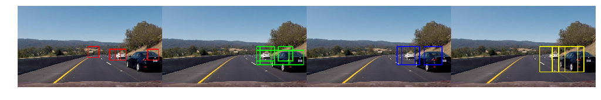

```python
import itertools, vehicles
import matplotlib.pyplot as plt

scales = [1.5,2,2.5,3.5]
drawing_images = [ img.copy() for scale in scales ]
colors = itertools.cycle( defaults.cv2Colors() )
for scale, image in zip(scales,drawing_images):
    vehicles.find_cars( img, image, scale = scale, color=next(colors))

fig, axes = plt.subplots(1, len(scales), figsize=(15,10))
fig.subplots_adjust(hspace=0, wspace=0, bottom=0, left=0, top=1, right=1)
for ax, image in zip(axes, drawing_images):
    ax.axis('off')
    ax.imshow(image)
```

From the above images, it is not clear how to choose the actual bounding boxes for the cars. The approach we will take is to construct a heatmap of pixels that occur inside detected windows. Specifically, for each bounding box that a pixel occurs within, its heatmap value will be incremented by 1. For instance, the heatmaps for the above images are shown in the following code snippet...

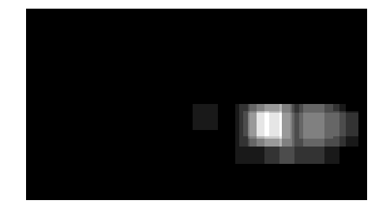

```python
import itertools, vehicles
import matplotlib.pyplot as plt

heatmap = np.zeros( img.shape[:2] )
colors = itertools.cycle( defaults.cv2Colors() )
for scale in scales:
    vehicles.find_cars( img, heatmap = heatmap, scale = scale, color=next(colors))

fig, ax = plt.subplots(1, 1)
fig.subplots_adjust(hspace=0, wspace=0, bottom=0, left=0, top=1, right=1)
ax.axis('off');
ax.imshow(heatmap, cmap = 'gray');
```

Next, we can threshold this heatmap to remove outliers. You can think of this thresholding as saying, "We won't label anything as a car unless there was a significant enough consensus between the SVM layers". So to compute the heatmap and threshold it with a specific value, we created the `vehicles.multiscale_finder` function.

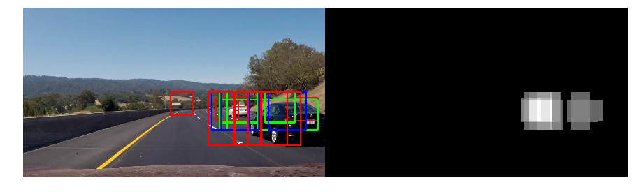

```python
threshold = 4
drawing_img, heatmap, imgs = vehicles.multiscale_finder(img, threshold=threshold, scales=scales )

fig,axes = plt.subplots(1,2, figsize=(12,7))
fig.subplots_adjust(hspace=0, wspace=0, bottom=0, left=0, top=1, right=1)
for ax in axes:
    ax.axis('off');
axes[0].imshow(drawing_img);
axes[1].imshow(heatmap, cmap = 'gray');
```

As you wil note from the above images, this thresholding does 2 important things:

1. Outliers tend to not occur in pairs (so points that are not cars are typically only picked up in 1 or 2 boxes).
2. When two cars are next to each other, the boundary between the cars tends to be included in 1 or 2 boxes. So thresholding helps to make the cars clearly distinguisable form each other.

Lastly, we want to drawing bounding boxes around the heatmaps. Fortunately, this turns out to be easy thanks to the `scipy.ndimage.measurements.label` method, which finds contiguous, nonzero values in an array, and assigns a label to each patch. For each of these labels, we can then find the extremities of the bounding boxes to define the car boundaries:

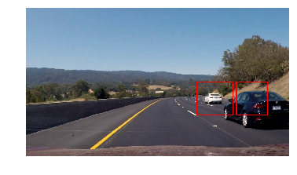

```python
imgWithBoxes = vehicles.draw_with_labels(img, scales=scales, threshold=threshold)
fig, ax = plt.subplots(1,1)
ax.axis('off');
ax.imshow(imgWithBoxes);
```

## Video Implementation

Now that we have a working pipeline for static images, let's see how it works on a video for a few threshold values:

```python
import base64, defaults, io, movify, os
from IPython.display import HTML

def video(filename):
    video = io.open(filename, 'r+b').read()
    encoded = base64.b64encode(video)
    HTML(data='''<video alt="test" controls>
                    <source src="data:video/mp4;base64,{0}" type="video/mp4" />
                 </video>'''.format(encoded.decode('ascii')))


inputVideo = 'project_video'
svc = defaults.svc()
scaler = defaults.scaler()
outputs = []
for threshold in range(2,6):
    stamp = str(threshold)
    output = 'output_images/' + inputVideo + '_' + stamp + '.mp4'
    outputs.append(output)
    if not os.path.isfile(output):
        movify.convert(inputVideo + '.mp4', output,
                       lambda x: vehicles.draw_with_labels(x, scales=scales, threshold=threshold, svc=svc, scaler=scaler))
```

[video not shown]

What we see from this is that when we use a low threshold, we get a lot of outliers popping up randomly in the image. Increasing the threshold imroves the performance a little bit, but at some point, we are essentially just ignoring everything (even true car detections). However there is still a glimmer of hope... The outliers tend not to be repeatable from frame to frame. This means that if we "average" across frames, then we may be able to get rid of the outliers. But the question is... how should we do that?

The most straight-forward answer seems to be to keep a running heatmap over the last `n` frames (e.g. `n=5`), and to then threshold that heatmap. The one danger is that we can't have the average over too many frames because of the car's motion.

> Note that we will now have two thresholds, one which is used to compute the heatmap for a single frame, and one that is used to threshold the conglomerate image.

To accomplish this task, we created the `vehicles.Summer` class (repeated here for clarity) which will keep a running sum of the heatmaps from the last `n` images:

```python
from collections import deque

class Summer():
    '''
    A class which stores a threshold and which will keep a
    running average of the heatmap over the last n frames
    '''
    def __init__(self, n, threshold):
        self.n = n
        self.frames = deque()
        self.summed = None
        self.threshold = threshold

    def addFrame(self, frame):
        ''' Add a frame to the deque of frames. '''
        if self.summed is None:
            self.summed = np.copy(frame)
            return np.copy(self.summed)
        elif len(self.frames) == self.n:
            # If the deque already holds the max number of elements...
            removed = self.frames.popleft()
            self.summed -= removed
        self.frames.append(np.copy(frame))
        self.summed += frame
        return np.copy(self.summed)
```

To use this class in the detection pipeline, you just create a non-None object and pass it to the `draw_with_labels` function (if you don't pass one, no previous frame data is used).

```python
inputVideo = 'project_video'
svc = defaults.svc()
scaler = defaults.scaler()
scales = [1.5, 1.75, 2, 2.25, 2.5, 2.75, 3 ]
scaleString = '_'.join((str(scale) for scale in scales))

s = 30
threshold1 = 7
summer = Summer(s, threshold1)
threshold2 = 120
stamp = str(s) + "_" + str(threshold1) + "_" + str(threshold2) + "_xxx_" + scaleString

output = 'output_images/' + inputVideo + '_' + stamp + '.mp4'
if not os.path.isfile(output):
    movify.convert(inputVideo + '.mp4', output,
               lambda x: vehicles.draw_with_labels(x, scales=scales, threshold=threshold2, svc=svc, scaler=scaler,
                                          summer=summer))
```

Now, unlike the previous case, we see some nice, stable detection rectangles that are fairly robust to outliers:

[video not shown]

## Discussion

I do not think that HOG features were a good choice for this project. They seemed to require a lot of ad-hoc tricks to get it to work for this project, and even then, I would say that it does not work well. I come to this conclusion based on the fact that 95% of the time confiuring this project was simply in tuning.

Furthermore, HOG features seem to be attractive since one might imagine that they are fast compared to a neural network approach. However, considering all of the scales we had to use to get the heatmap approach working, we are only achieving about 6fps. I would guess that we could get much better accuracy and speed by using a simple neural network.

Finally, based on how much tuning was required to get just the accuracy shown above, I would guess that the trained network probably will not generalize well to other road environments.